# Webscraping Project - Analysising Metacritic Videogame Reviews

Jeremy Osir

10/4/2021

# Next steps: Clean up Platform Charts, Add Hall of Fame/Shame tables, Knit!

## 1. Data Preprocessing

### 1.1 Load libraries

```r
library(tidyverse)
library(lubridate)
library(janitor)
library(dplyr)
library(ggplot2)
library(readr)
library(skimr)
library(data.table)
library(formattable)
```

### 1.2 Load dataset

```r
game.reviews <- read.csv("./metacritic_VGreviews.csv")
```

### 1.3 Clean data

```r
# Review summary information about the game reviews dataframe
skim(game.reviews)
```

Data summary

| Name | game.reviews |
| --- | --- |
| Number of rows | 17087 |
| Number of columns | 20 |
| _______________________ |  |
| Column type frequency: |  |
| character | 11 |
| numeric | 9 |
| ________________________ |  |
| Group variables | None |

**Variable type: character**

| skim_variable | n_missing | complete_rate | min | max | empty | n_unique | whitespace |
| --- | --- | --- | --- | --- | --- | --- | --- |
| critic_consensus | 0 | 1 | 12 | 29 | 0 | 6 | 0 |
| developer | 0 | 1 | 0 | 48 | 17 | 3432 | 0 |
| esrb_rating | 0 | 1 | 0 | 4 | 1783 | 8 | 0 |
| game_summary | 0 | 1 | 0 | 5324 | 101 | 13410 | 0 |
| game_summary_long | 0 | 1 | 0 | 3588 | 4534 | 9823 | 2 |
| genres | 0 | 1 | 12 | 114 | 0 | 2018 | 0 |
| num_players | 0 | 1 | 2 | 21 | 0 | 57 | 0 |
| platform | 0 | 1 | 2 | 16 | 0 | 22 | 0 |
| release_date | 0 | 1 | 12 | 12 | 0 | 4328 | 0 |
| title | 0 | 1 | 2 | 94 | 0 | 11210 | 0 |
| user_consensus | 0 | 1 | 17 | 29 | 0 | 5 | 0 |

**Variable type: numeric**

| skim_variable | n_missing | complete_rate | mean | sd | p0 | p25 | p50 | p75 | p100 | hist |
| --- | --- | --- | --- | --- | --- | --- | --- | --- | --- | --- |
| critic_score_mix | 8653 | 0.49 | 65.42 | 6.53 | 50.0 | 61.0 | 67.0 | 71.0 | 74.0 | ▂▃▅▆▇ |
| critic_score_neg | 16019 | 0.06 | 41.36 | 6.85 | 11.0 | 38.0 | 43.0 | 47.0 | 49.0 | ▁▁▁▃▇ |
| critic_score_pos | 9504 | 0.44 | 81.42 | 4.79 | 75.0 | 78.0 | 81.0 | 84.0 | 99.0 | ▇▇▃▁▁ |
| num_critic_reviews | 0 | 1.00 | 23.94 | 17.46 | 0.0 | 11.0 | 18.0 | 31.0 | 126.0 | ▇▃▁▁▁ |
| num_user_reviews | 0 | 1.00 | 194.02 | 1398.84 | 4.0 | 14.0 | 33.0 | 101.0 | 153585.0 | ▇▁▁▁▁ |
| rank | 0 | 1.00 | 8936.22 | 5320.38 | 1.0 | 4313.5 | 8772.0 | 13491.5 | 18433.0 | ▇▇▇▇▇ |
| user_score_mix | 9016 | 0.47 | 6.54 | 0.67 | 5.0 | 6.1 | 6.7 | 7.1 | 7.4 | ▂▃▅▆▇ |
| user_score_neg | 15626 | 0.09 | 3.84 | 0.94 | 0.2 | 3.4 | 4.1 | 4.6 | 4.9 | ▁▁▂▃▇ |
| user_score_pos | 9532 | 0.44 | 8.08 | 0.42 | 7.5 | 7.7 | 8.0 | 8.4 | 9.8 | ▇▆▃▁▁ |

```r
  # 17K observations with 20 variables/features
  # there are no missing values in the 11 character columns
  # numeric columns have missing values, but those seem to be bc reviews are stored in different fields


#### Pre-Processing Steps ####
# 1. Convert "release date" column from character to date
game.reviews.df <- game.reviews %>%
  mutate(., release_date = mdy(release_date)) # Dates in format: "Month - Day - Year"

sapply(game.reviews.df, class) # check variable classes
```

```
##   critic_consensus   critic_score_mix   critic_score_neg   critic_score_pos
##        "character"          "integer"          "integer"          "integer"
##          developer        esrb_rating       game_summary  game_summary_long
##        "character"        "character"        "character"        "character"
##             genres num_critic_reviews        num_players   num_user_reviews
##        "character"          "integer"        "character"          "integer"
##           platform               rank       release_date              title
##        "character"          "integer"             "Date"        "character"
##     user_consensus     user_score_mix     user_score_neg     user_score_pos
##        "character"          "numeric"          "numeric"          "numeric"
```

```r
# 2. Create new column that extracts the year from release_date
game.reviews.df <- game.reviews.df %>%
  mutate(., release_year = year(release_date))

# 3. The critic and user review scores are stored in different columns based on whether they are positive, mixed, or negative. Create ONE column to store all the critic reviews
game.reviews.df <-game.reviews.df %>%
  mutate(., critic_score = case_when(
    is.na(critic_score_pos) & is.na(critic_score_mix) ~ critic_score_neg,
    is.na(critic_score_neg) & is.na(critic_score_pos) ~ critic_score_mix,
    is.na(critic_score_mix) & is.na(critic_score_neg) ~ critic_score_pos,
    TRUE ~ critic_score_pos
  ))

  # Two games do not have any critic reviews (Kalypso and Eggtooth Team). Exclude them from the dataset
game.reviews.df <-  game.reviews.df %>%
  filter(., !is.na(critic_score))

# Next, repeat the same process for the user review columns
game.reviews.df <- game.reviews.df %>%
  mutate(., user_score = case_when(
    is.na(user_score_pos) & is.na(user_score_mix) ~ user_score_neg,
    is.na(user_score_neg) & is.na(user_score_pos) ~ user_score_mix,
    is.na(user_score_mix) & is.na(user_score_neg) ~ user_score_pos,
    TRUE ~ user_score_pos
  ))

# The critic scores are given on a 1-100 scale, while the user scores are 1-10 (to 1 decimal place)
# Scale the critic-score by 0.1 so that it matches the user score format
game.reviews.df <- game.reviews.df %>%
  mutate(critic_score_scaled = critic_score/10)

## Genres are all stored in one column. Let's split them into seperate columns

  # Check the maximum no. of genres that a single game in the dataset has
max(lengths(strsplit(game.reviews.df$genres, ','))) # 12 genres
```

```
## [1] 12
```

```r
# Use 'str_split_fixed' function to split each genre in the genres column into individual columns
  # NOTE: since there are duplicate genres, let's plan to remove dupes after making the df longer
genre.columns <- str_split_fixed(game.reviews.df$genres, ",", 12)

# combine the genre
reviews.genres <- cbind(game.reviews.df, genre.columns)

# gather the dataframe and make it long
genres.long <- pivot_longer(reviews.genres,
                            cols = "1":"12", names_to = "genre.ID", values_to = "genre.value")

# Each title's genres are captured in a separate row.
# Remove any rows that have an empty genre.value and/or a duplicated value
genres.long <- genres.long %>%
  filter(., !genre.value == "")


reviews.genres.long <- genres.long %>%
  distinct(., title, platform, genre.value, .keep_all = TRUE)
```

## 2. Data Visualization

### Questions we want to answer from this dataset

- How do user scores compare to critic scores - overall? IS there a correlation?
- How have user & critic reviews trended over time?
- Which platforms have the highest reviews, on average according to 1) critics, 2) users?
- Which platform has the most games ranked in the top 100? Bottom 100?
- Which videogame genres scored highest in the eyes of 1) critics, 2) users?
- Which videogames are in the Hall of Fame? Which are in the the Hall of Shame?
- Do my favorite games perform better or worse in than the rest of the games?

### 2.1 Inspection: Compare distribution of user scores vs critic scores? Is there a correlation?

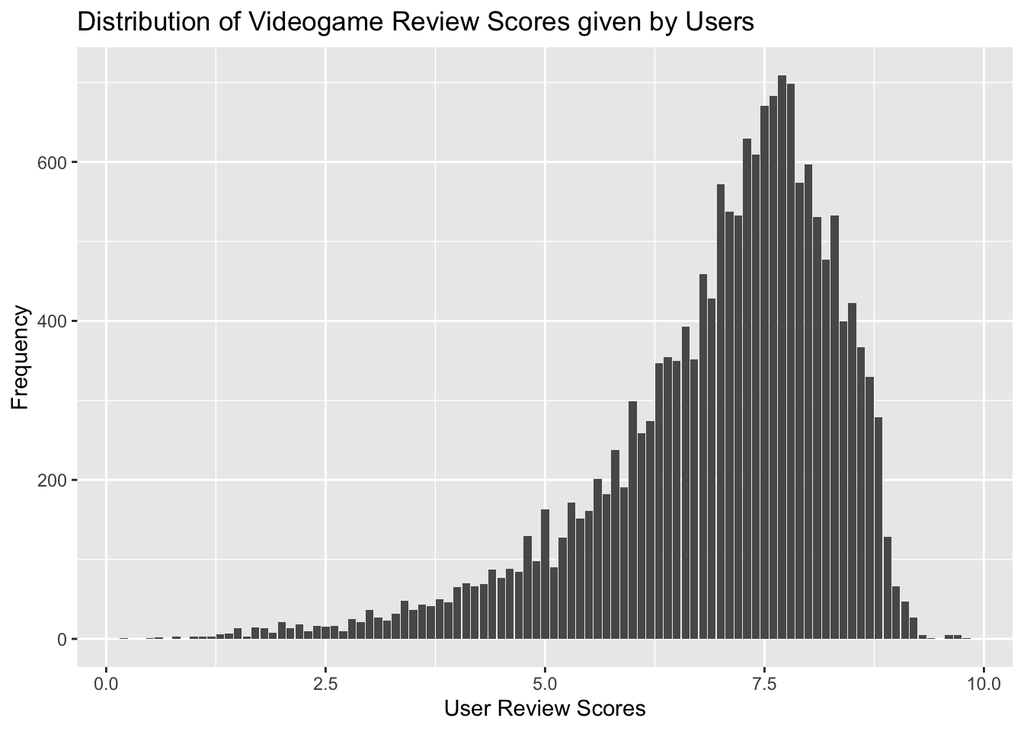

```r
# Create some charts to explore the distribution  data
  # User score frequency plot
user.reviews.distr <-game.reviews.df %>%
  ggplot(data = ., aes(x = user_score)) +
  geom_bar(position = "dodge") +
  labs(title = "Distribution of Videogame Review Scores given by Users",
       x= "User Review Scores", y = "Frequency")

user.reviews.distr
```

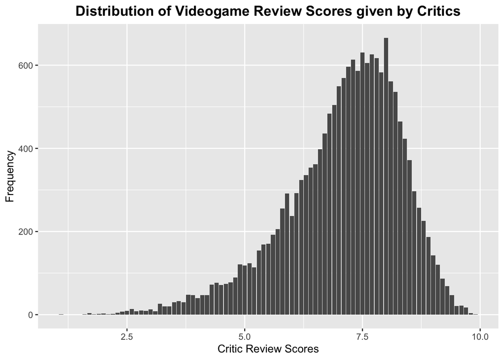

```r
  # Critic score frequency plot
critic.reviews.distr <- game.reviews.df %>%
  ggplot(., aes(x = critic_score_scaled)) +
  geom_bar(position = "dodge")+
  labs(title = "Distribution of Videogame Review Scores given by Critics",
       x= "Critic Review Scores", y = "Frequency") +
  theme(plot.title = element_text(hjust = 0.5, size = 14, face = "bold"))
critic.reviews.distr
```

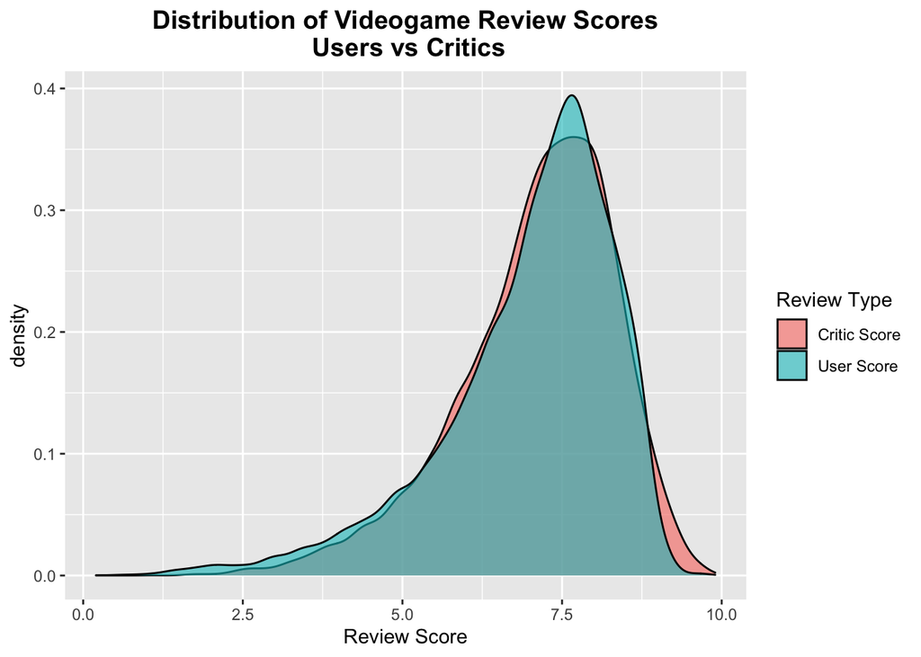

```r
  # Overlap critic and user score distribution on one chart

# Let's observe density plots for the user and critic reviews
game.reviews.distr <- game.reviews.df %>%
  pivot_longer(., cols = c(user_score, critic_score_scaled), names_to = "review_type", values_to = "review_score") %>%
  ggplot(., aes(x = review_score, fill = review_type))+
  geom_density(alpha = 0.6) +
  labs(title = "Distribution of Videogame Review Scores\n Users vs Critics",
       x = "Review Score",
       fill = "Review Type")+
  theme(plot.title = element_text(hjust = 0.5, size = 14, face = "bold"))+
  scale_fill_discrete(labels = c("Critic Score", "User Score"))
game.reviews.distr
```

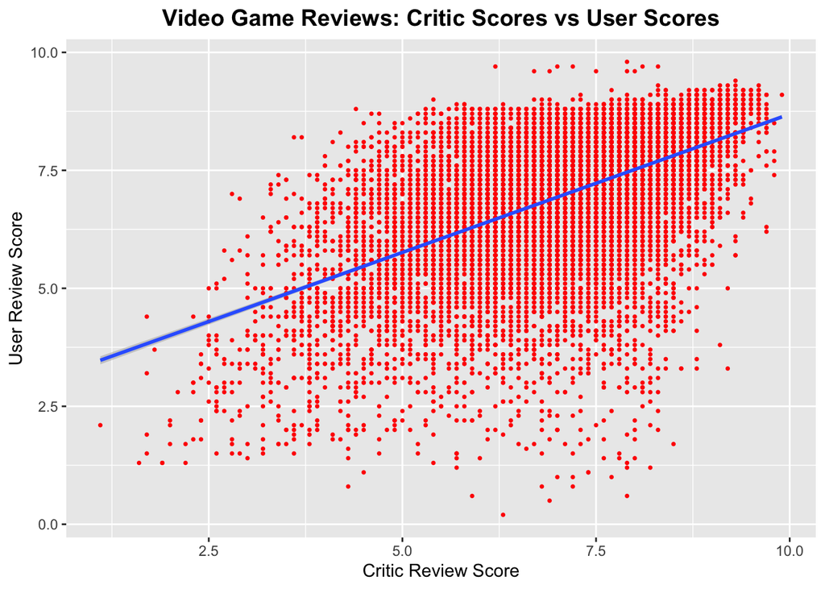

```r
# Correlation between user and critic scores ####
scatter.user.critic.reviews <- game.reviews.df %>%
  ggplot(., aes(x = critic_score_scaled, y = user_score))+
  labs(title = "Video Game Reviews: Critic Scores vs User Scores", x= "Critic Review Score", y = "User Review Score") +
  geom_point(size = 0.6, color = "red")+
  geom_smooth(method = "lm") +
  theme(plot.title = element_text(hjust = 0.5, size = 14, face = "bold"))
scatter.user.critic.reviews
```

```r
# Check correlation between critic score and user score
cor.test(game.reviews.df$critic_score_scaled, game.reviews.df$user_score, method = "pearson", conf.level = 0.95)
```

```
##
##  Pearson's product-moment correlation
##
## data:  game.reviews.df$critic_score_scaled and game.reviews.df$user_score
## t = 82.739, df = 17083, p-value < 2.2e-16
## alternative hypothesis: true correlation is not equal to 0
## 95 percent confidence interval:
##  0.5240806 0.5454922
## sample estimates:
##       cor
## 0.5348723
```

```r
  # Pearson's correlation test indicates user and critic scores have a correlation = 0.53, and is statistically significant
  # Takeaway: User and Critic Scores are moderately positively correlated, with scores generally following the same pattern
```

### 2.2 Inspection: Examine how the average review scores given by users and critics has changed over time.

Check whether the difference in review scores has got larger or smaller.

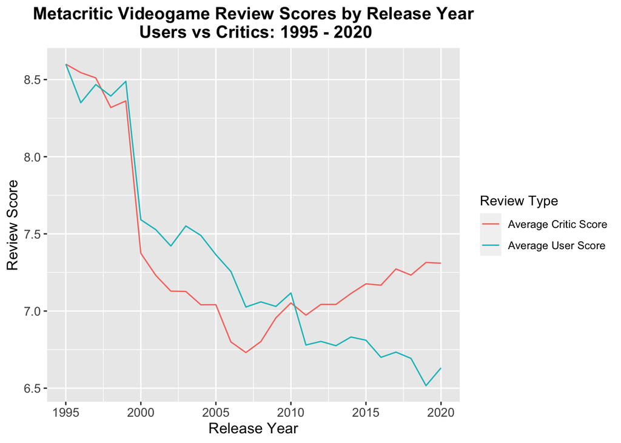

```r
# Title Reviews by Year - comparing critic scores vs user scores ####
users.critics.annual <- game.reviews.df %>%
  group_by(.,release_year) %>%
  filter(., !release_year == 2021) %>%
  summarise(., avg.annual.critic.score = mean(critic_score_scaled),
            avg.annual.user.score = mean(user_score)) %>%
  mutate(., score.difference = avg.annual.critic.score - avg.annual.user.score)

user.critics.annual.chart <- users.critics.annual %>%
  pivot_longer(., cols = !c(release_year,score.difference), names_to = 'review_type', values_to = "review_score") %>%
  ggplot(., aes(x = release_year, y = review_score, color = review_type))+
  geom_line() +
  labs(title = "Metacritic Videogame Review Scores by Release Year\n Users vs Critics: 1995 - 2020",
       x= "Release Year", y = "Review Score",
       color = "Review Type") +
  scale_color_hue(labels = c("Average Critic Score", "Average User Score")) +
  theme(axis.text.x = element_text(size = 10), axis.title.x = element_text(size = 12),
        axis.text.y = element_text(size = 10), axis.title.y = element_text(size = 12),
        plot.title = element_text(hjust = 0.5, size = 14, face = "bold"))

user.critics.annual.chart
```

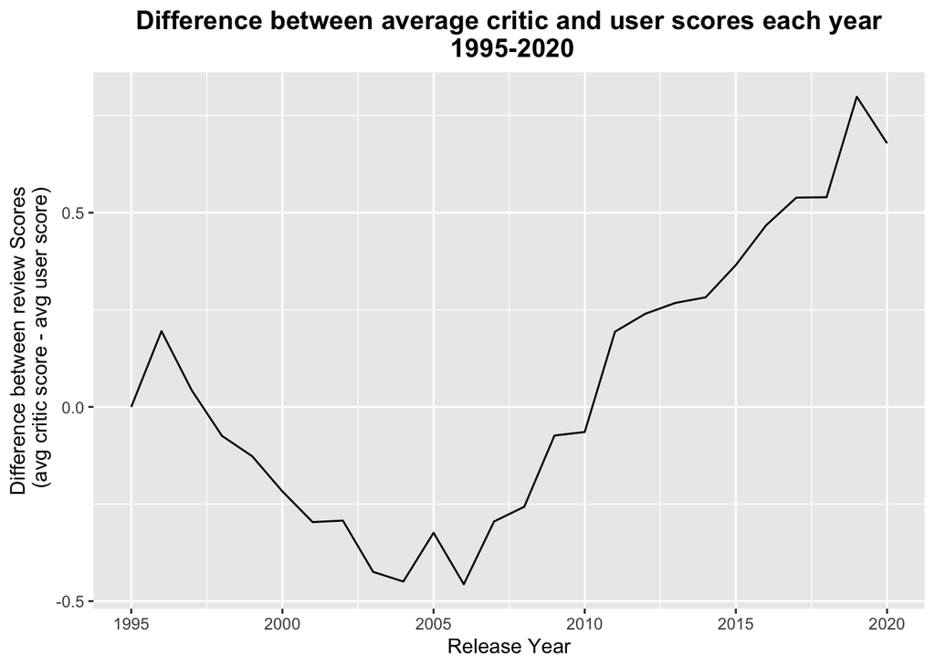

```r
# Let's look at how much the scores have diverged over time
user.critics.score.diff <- users.critics.annual %>%
  ggplot(., aes(x = release_year, y = score.difference))+
  geom_line() +
  labs(title = "Difference between average critic and user scores each year\n 1995-2020",
       x= "Release Year", y = "Difference between review Scores\n (avg critic score - avg user score)") +
  theme(plot.title = element_text(hjust = 0.5, size = 14, face = "bold"))

user.critics.score.diff
```

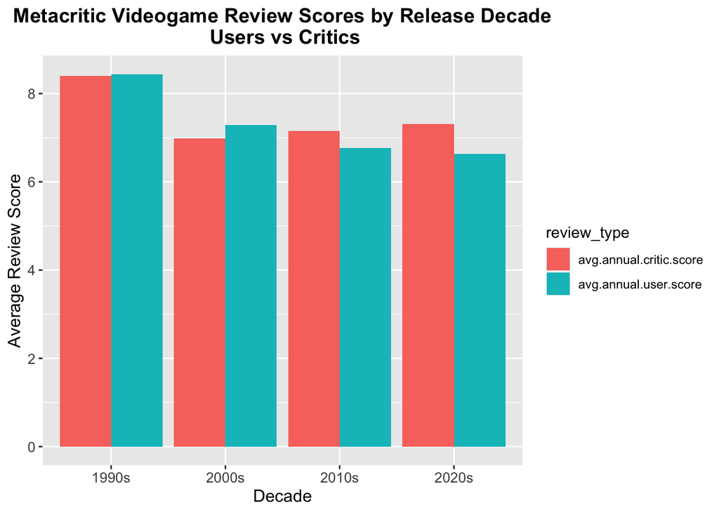

```r
# Title Reviews by Decade ####
title.reviews.decade <- game.reviews.df %>%
  filter(., !release_year == 2021) %>%
  mutate(., release_decade = case_when(
    release_year %in% c(1990,1991,1992,1993,1994,1995,1996,1997,1998,1999) ~ "1990s",
    release_year %in% c(2000,2001,2002,2003,2004,2005,2006,2007,2008,2009) ~ "2000s",
    release_year %in% c(2010,2011,2012,2013,2014,2015,2016,2017,2018,2019) ~ "2010s",
    TRUE ~ "2020s")) %>%
  group_by(., release_decade) %>%
  summarise(., avg.annual.critic.score = mean(critic_score_scaled),
            avg.annual.user.score = mean(user_score)) %>%
  pivot_longer(., cols = !release_decade, names_to = 'review_type', values_to = "review_score")


title.reviews.decade.chart <- title.reviews.decade %>%
  ggplot(., aes(x = release_decade, y = review_score, fill= review_type, group = review_type))+
  geom_col(position = "dodge") +
  labs(title = "Metacritic Videogame Review Scores by Release Decade\n Users vs Critics",
       x= "Decade", y = "Average Review Score",
       color = "Review Type") +
  scale_color_hue(labels = c("Average Critic Score", "Average User Score")) +
  theme(axis.text.x = element_text(size = 10), axis.title.x = element_text(size = 12),
        axis.text.y = element_text(size = 10), axis.title.y = element_text(size = 12),
        plot.title = element_text(hjust = 0.5, size = 14, face = "bold"))

title.reviews.decade.chart
```

```r
# On average, user review scores have gone down over time.
# The 90s have the highest reviews by users and critics. (Partially due to fewer games being released)
# The average review scores dropped by almost 1- 1.5pts in the 2000s.
# By the 2010s, we start seeing more divergence between critics and users, with users being more critical.
```

## 2.3. Inspection: How has the number of user & critics providing reviews changed over time?

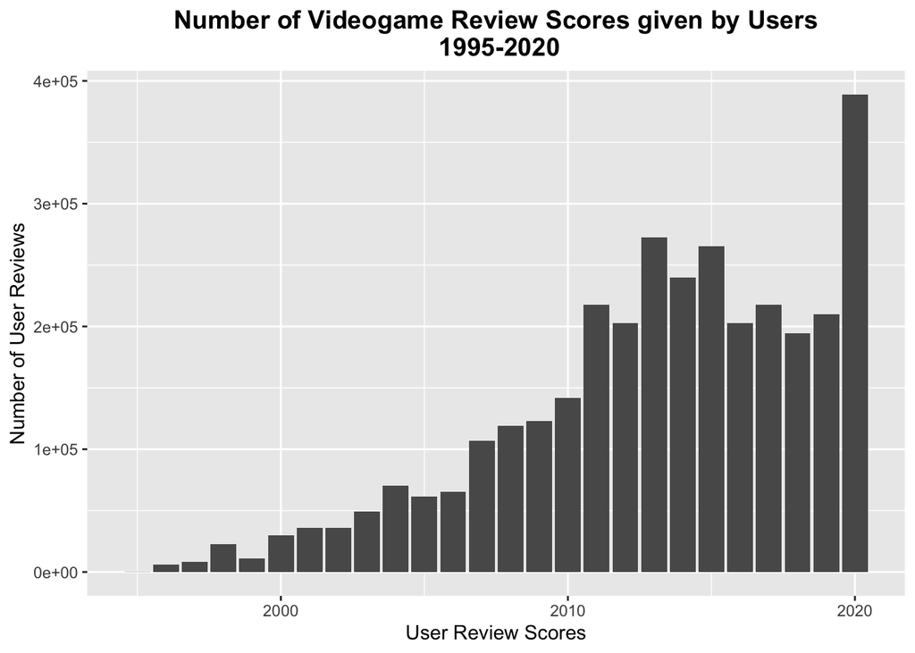

```r
# How have number of user provided reviews trended over time?
user.reviews.freq <- game.reviews.df %>%
  group_by(., release_year) %>%
  filter(., !release_year == 2021) %>%
  summarise(., total_num_user_reviews = sum(num_user_reviews)) %>%
  ggplot(., aes(x = release_year, y = total_num_user_reviews))+
  geom_col() +
  labs(title = "Number of Videogame Review Scores given by Users\n 1995-2020",
       x= "User Review Scores", y = "Number of User Reviews") +
  theme(plot.title = element_text(hjust = 0.5, size = 14, face = "bold"))
user.reviews.freq
```

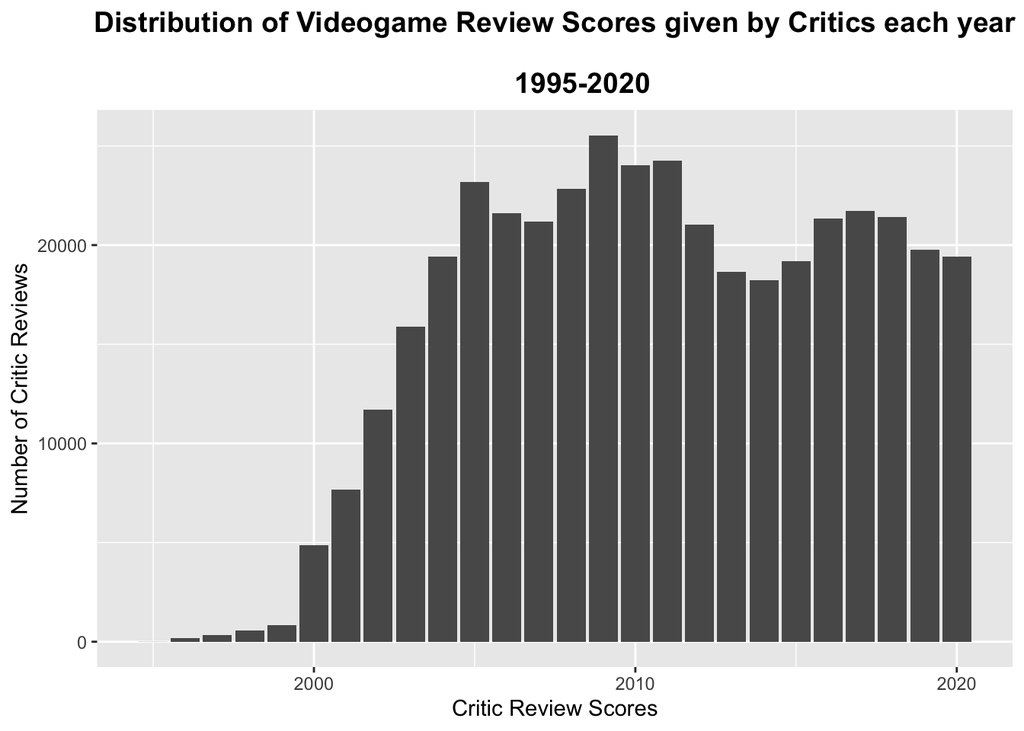

```r
# Over time, the number of user reviews has risen sharply (to be expected)
# User reviews also dwarf critic reviews (400K user reviews in 2020 compared to 20K critic reviews)

critic.reviews.freq <- game.reviews.df %>%
  group_by(., release_year) %>%
  filter(., !release_year == 2021) %>%
  summarise(., total_num_critic_reviews = sum(num_critic_reviews)) %>%
  ggplot(., aes(x = release_year, y = total_num_critic_reviews))+
  geom_col()+
  labs(title = "Distribution of Videogame Review Scores given by Critics each year\n
       1995-2020",
       x= "Critic Review Scores", y = "Number of Critic Reviews") +
  theme(plot.title = element_text(hjust = 0.5, size = 14, face = "bold"))

critic.reviews.freq
```

## 2.4 Inspection:

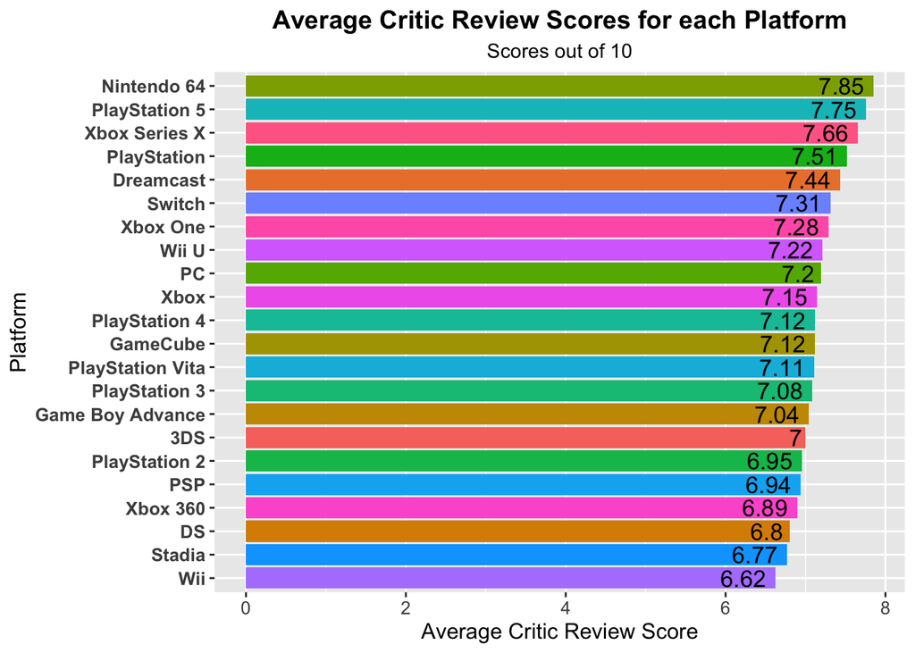

```r
# Platform Reviews ####
platform.reviews <- game.reviews.df %>%
  group_by(., platform) %>%
  summarise(., avg.annual.critic.score = mean(critic_score_scaled),
            avg.annual.user.score = mean(user_score)) %>%
  pivot_longer(., cols = !platform, names_to = "review_type", values_to = "review_score")

  # Platform with highest reviews according to Critics
platform.critic.reviews.chart <- platform.reviews %>%
  filter(., review_type == "avg.annual.critic.score") %>%
  ggplot(., aes(x = reorder(platform, review_score), y =review_score, fill = platform))+
  geom_bar(stat = "identity") +
  geom_text(aes(label = round(review_score,2), hjust = 1.2, size = 1, face = "bold")) +
  labs(title = "Average Critic Review Scores for each Platform",
    subtitle = "Scores out of 10",
    x= "Platform",
    y = "Average Critic Review Score") +
  scale_fill_discrete() +
  theme(axis.text.x = element_text(size = 10), axis.title.x = element_text(size = 12),
        axis.text.y = element_text(size = 10, face = "bold"), axis.title.y = element_text(size = 12),
        plot.title = element_text(size = 14, face = "bold", hjust = 0.5,),
        plot.subtitle = element_text(hjust = 0.5),
        legend.position = "none") +
  coord_flip()
  # geom_hline(yintercept = mean(game.reviews.df$critic_score_scaled,
  #                               linetype = "dashed", color = "purple", size = 1.1))

platform.critic.reviews.chart
```

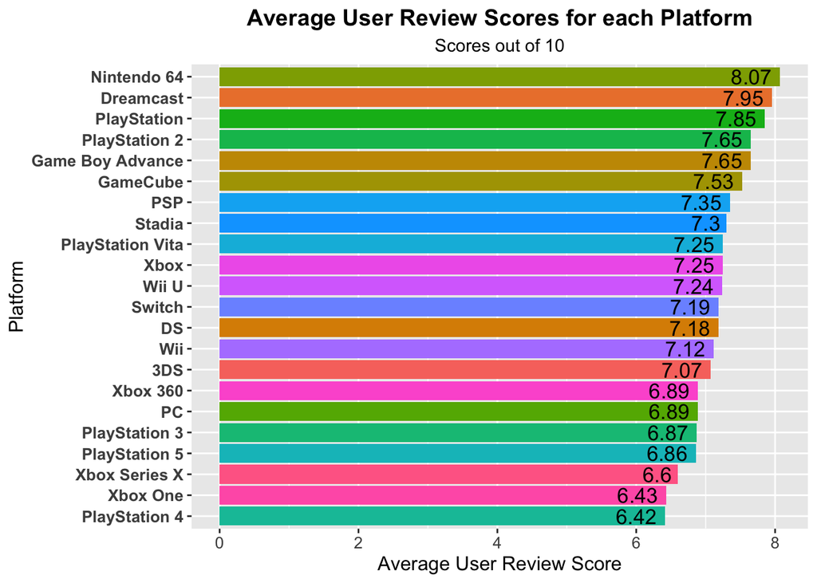

```r
  # User Reviews
platform.user.reviews.chart <- platform.reviews %>%
  filter(., review_type == "avg.annual.user.score") %>%
  ggplot(., aes(x = reorder(platform, review_score), y = review_score, fill = platform))+
  geom_bar(stat = "identity") +
  geom_text(aes(label = round(review_score,2), hjust = 1.2, size = 1, face = "bold")) +
  labs(
    title = "Average User Review Scores for each Platform",
    subtitle = "Scores out of 10",
    x= "Platform",
    y = "Average User Review Score") +
  scale_fill_discrete() +
  theme(axis.text.x = element_text(size = 10), axis.title.x = element_text(size = 12),
        axis.text.y = element_text(size = 10, face = "bold"), axis.title.y = element_text(size = 12),
        plot.title = element_text(size = 14, face = "bold", hjust = 0.5,),
        plot.subtitle = element_text(hjust = 0.5),
        legend.position = "none")+
  coord_flip()
  #geom_hline(yintercept = mean(game.reviews.df$user_score,
                               #linetype = "dashed", color = "purple", size = 1.1))

platform.user.reviews.chart
```

```r
# Create a dataframe showing the number of genres that each title is associated with
count.genres.per.game <- genres.long %>%
  filter(., !genre.value == " ") %>%
  group_by(., platform, title) %>%
  summarize(num_genres = n())
count.genres.per.game
```

```
## # A tibble: 17,085 x 3
## # Groups:   platform [22]
##    platform title                          num_genres
##    <chr>    <chr>                               <int>
##  1 3DS      3D After Burner II                      5
##  2 3DS      3D Classics: Kid Icarus                 5
##  3 3DS      3D Classics: Kirby's Adventure          5
##  4 3DS      3D Classics: TwinBee                    7
##  5 3DS      3D Classics: Urban Champion             5
##  6 3DS      3D Classics: Xevious                    7
##  7 3DS      3D Gunstar Heroes                       4
##  8 3DS      3D Out Run                              4
##  9 3DS      3D Sonic the Hedgehog 2                 3
## 10 3DS      3D Streets of Rage II                   3
## # … with 17,075 more rows
```